# Sample Splitting with Caret

We can train the model with the `caret` package (for further information about `caret`, see [the original website](http://topepo.github.io/caret/index.html)). We use parallel computing to speed up the computation.

```r
# parallel computing
library(doParallel)
cl <- makePSOCKcluster(5)
registerDoParallel(cl)

# stop after finishing the computation
stopCluster(cl)
```

The following example shows how to estimate the ITR with grandient boosting machine (GBM) using the `caret` package. Note that we have already loaded the data and specify the treatment, outcome, and covariates as shown in the Sample Splitting vignette. Since we are using the `caret` package, we need to specify the `trainControl` and/or `tuneGrid` arguments. The `trainControl` argument specifies the cross-validation method and the `tuneGrid` argument specifies the tuning grid. For more information about these arguments, please refer to the [caret website](http://topepo.github.io/caret/model-training-and-tuning.html).

We estimate the ITR with only one machine learning algorithm (GBM) and evaluate the ITR with the `evaluate_itr()` function. To compute `PAPDp`, we need to specify the `algorithms` argument with more than 2 machine learning algorithms.

```r
library(evalITR)

# specify the trainControl method
fitControl <- caret::trainControl(
  method = "repeatedcv", # 3-fold CV
  number = 3, # repeated 3 times
  repeats = 3,
  search='grid',
  allowParallel = TRUE) # grid search

# specify the tuning grid
gbmGrid <- expand.grid(
  interaction.depth = c(1, 5, 9),
  n.trees = (1:30)*50,
  shrinkage = 0.1,
  n.minobsinnode = 20)

# estimate ITR
fit_caret <- estimate_itr(
  treatment = "treatment",
  form = user_formula,
  trControl = fitControl,
  data = star_data,
  algorithms = c("gbm"),
  budget = 0.2,
  split_ratio = 0.7,
  tuneGrid = gbmGrid,
  verbose = FALSE)
```

```
#> Evaluate ITR under sample splitting ...
```

```r
# evaluate ITR
est_caret <- evaluate_itr(fit_caret)
```

```
#> Cannot compute PAPDp
```

We can extract the training model from `caret` and check the model performance. Other functions from `caret` can be applied to the training model.

```r
# extract the final model
caret_model <- fit_caret$estimates$models$gbm
print(caret_model$finalModel)
```

```
#> A gradient boosted model with gaussian loss function.
#> 50 iterations were performed.
#> There were 53 predictors of which 40 had non-zero influence.
```

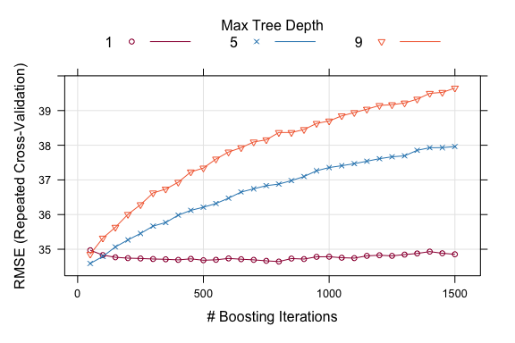

```r
# check model performance
trellis.par.set(caretTheme()) # theme
plot(caret_model)
```

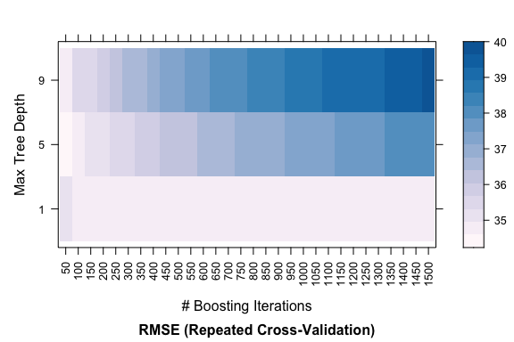

```r
# heatmap
plot(
  caret_model,
  plotType = "level",
  scales = list(x = list(rot = 90)))
```

The`summary()` function displays the following summary statistics: (1) population average prescriptive effect `PAPE`; (2) population average prescriptive effect with a budget constraint `PAPEp`; (3) population average prescriptive effect difference with a budget constraint `PAPDp`. This quantity will be computed with more than 2 machine learning algorithms); (4) and area under **the** prescriptive effect curve `AUPEC`. For more information about these evaluation metrics, please refer to [Imai and Li (2021)](https://arxiv.org/abs/1905.05389); (5) Grouped Average Treatment Effects `GATEs`. The details of the methods for this design are given in [Imai and Li (2022)](https://arxiv.org/abs/2203.14511).

```r
# summarize estimates
summary(est_caret)
```

```
#> ── PAPE ────────────────────────────────────────────────────────────────────────
#>   estimate std.deviation algorithm statistic p.value
#> 1     -1.5           1.3       gbm      -1.2    0.24
#>
#> ── PAPEp ───────────────────────────────────────────────────────────────────────
#>   estimate std.deviation algorithm statistic p.value
#> 1      1.1           1.1       gbm         1     0.3
#>
#> ── PAPDp ───────────────────────────────────────────────────────────────────────
#> data frame with 0 columns and 0 rows
#>
#> ── AUPEC ───────────────────────────────────────────────────────────────────────
#>   estimate std.deviation algorithm statistic p.value
#> 1    -0.47          0.97       gbm     -0.49    0.63
#>
#> ── GATE ────────────────────────────────────────────────────────────────────────
#>   estimate std.deviation algorithm group statistic p.value upper lower
#> 1    -52.9           107       gbm     1    -0.495   0.621  -229   123
#> 2    148.2           108       gbm     2     1.375   0.169   -29   325
#> 3      7.8           108       gbm     3     0.072   0.943  -170   185
#> 4   -230.2           107       gbm     4    -2.154   0.031  -406   -54
#> 5    140.4           108       gbm     5     1.295   0.195   -38   319
```

We plot the estimated Area Under the Prescriptive Effect Curve for the writing score across a range of budget constraints for the gradient boosting machine.

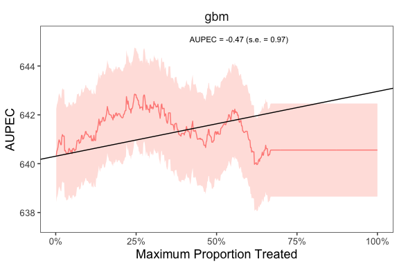

```r
# plot the AUPEC
plot(est_caret)
```